# Week1 One-way ANOVA

# 背景描述

为了调查吃巧克力对心血管健康的影响，实验由三种类型的巧克力组成：100g的黑巧克力，含有200mg全脂牛奶的100g黑巧克力和200g的牛奶巧克力。12个实验对象：7女5男。在不同的天数里，每个实验对象将吃一种类型的巧克力，一个小时后测量他们血浆的总抗氧能力。 这是一个因子水平数 𝑎 = 3 和重复次数 m = 12 的单因子实验。

# 数据描述

实验次序本身具有随机性，无需再随机化

| 变量名 | 变量含义 | 变量类型 | 变量取值范围 |
| --- | --- | --- | --- |
| （自变量）Chocolate | 巧克力类型 | categorical variable | [1, 2, 3] |
| （因变量）Capacity | 血浆浓度 | continuous variable | Real |

```python
import pandas as pd
print('Randomized test sequence: \n', pd.read_csv('Project1.csv'))
```

```
Randomized test sequence:
     Obs  Chocolate  Capacity
0     1          1     118.8
1     2          1     122.6
2     3          1     115.6
3     4          1     113.6
4     5          1     119.5
5     6          1     115.9
6     7          1     115.8
7     8          1     115.1
8     9          1     116.9
9    10          1     115.4
10   11          1     115.6
11   12          1     107.9
12    1          2     105.4
```

[output cut: 23 more lines]

# 问题

注：这里使用 \alpha=0.05 的显著性水平

1. 试用两样本t检验两两比较 3 种巧克力对心血管健康的影响是否存在差异.
2. 试使用One-way ANOVA判断食用的 3 种巧克力对心血管健康的影响是否有差异.
3. 试判断该实验用One-way ANOVA模型是否恰当.
4. 估计食用这 3 种巧克力 1h 后血浆的总抗氧能力均值和误差的方差.

# 解决方案

```python
# Import standard packages
import numpy as np
import pandas as pd
import scipy.stats as stats # 统计函数
import matplotlib.pyplot as plt
import math

# Import additional packages
from statsmodels.formula.api import ols
from statsmodels.stats.anova import anova_lm
from scipy.stats import f
from scipy.stats import t

alpha = 0.05
a = 3
m = 12
df = pd.read_csv('Project1.csv')
# print(df.columns)
df = df[['Chocolate', 'Capacity']]
df.columns = ['Type','Capacity']
print(df)

# Sort them into groups, according to column 1("Power")
data = df.values # .values will turn pandas into Numpy
list_type = [1, 2, 3]
groups = [data[data[:,0] == atype,1] for atype in list_type]
```

```
    Type  Capacity
0      1     118.8
1      1     122.6
2      1     115.6
3      1     113.6
4      1     119.5
5      1     115.9
6      1     115.8
7      1     115.1
8      1     116.9
9      1     115.4
10     1     115.6
11     1     107.9
12     2     105.4
13     2     101.1
```

[output cut: 22 more lines]

# Q1: 试用两样本t检验两两比较 3 种巧克力对心血管健康的影响是否存在差异.

```python
# 查看 两样本t检验(假设检验) 的 t值和p值,用于判断是否接受原假设
t0, pVal0 = stats.ttest_ind(groups[0], groups[1])

# 法1：
if pVal0 < alpha:
    print('Since p-value =', round(pVal0, 3), '< 0.05, reject H0.')
else:
    print('Accept H0.')

# 法2：
t_val = t.ppf(1 - alpha / 2, 2 * m - 2)
if abs(t0) > abs(t_val):
    print('Since t0 =', round(t0, 3),', t_val =', round(t_val, 3), ', reject H0.')
else:
    print('Accept H0.')
```

```
Since p-value = 0.0 < 0.05, reject H0.
Since t0 = 11.106 , t_val = 2.074 , reject H0.
```

```python
# 查看 两样本t检验(假设检验) 的 t值和p值,用于判断是否接受原假设
t0, pVal0 = stats.ttest_ind(groups[0], groups[2])

# 法1：
if pVal0 < alpha:
    print('Since p-value =', round(pVal0, 3), '< 0.05, reject H0.')
else:
    print('Accept H0.')

# 法2：
t_val = t.ppf(1 - alpha / 2, 2 * m - 2)
if abs(t0) > abs(t_val):
    print('Since t0 =', round(t0, 3),', t_val =', round(t_val, 3), ', reject H0.')
else:
    print('Accept H0.')
```

```
Since p-value = 0.0 < 0.05, reject H0.
Since t0 = 12.048 , t_val = 2.074 , reject H0.
```

```python
# 查看 两样本t检验(假设检验) 的 t值和p值,用于判断是否接受原假设
t0, pVal0 = stats.ttest_ind(groups[1], groups[2])

# 法1：
if pVal0 < alpha:
    print('Since p-value =', round(pVal0, 3), '< 0.05, reject H0.')
else:
    print('Accept H0.')

# 法2：
t_val = t.ppf(1 - alpha / 2, 2 * m - 2)
if abs(t0) > abs(t_val):
    print('Since t0 =', round(t0, 3),', t_val =', round(t_val, 3), ', reject H0.')
else:
    print('Accept H0.')
```

```
Accept H0.
Accept H0.
```

# Q2: 试使用One-way ANOVA判断食用的 3 种巧克力对心血管健康的影响是否有差异.

检验假设 H0:μ1=μ2=μ3 ; H1:μ1,μ2,μ3 不全相等

```python
# Do the one-way ANOVA
model = ols('Capacity ~ C(Type)', df).fit()
anovaResults = round(anova_lm(model), 2)
print('\nThe ANOVA table: \n', anovaResults)

F0, pVal1 = stats.f_oneway(groups[0], groups[1], groups[2]) # F统计量和p值
# 法1：
if pVal1 < alpha:
    print('\nSince p-value =', round(pVal1, 3), '< 0.05, reject H0.')
else:
    print('\nAccept H0.')

# 法2：
F = f.ppf(1 - alpha, dfn = a - 1, dfd = a * (m - 1))
if F0 > F:
    print('\nSince F0 =', round(F0, 3),'> F(0.05,2,33) =', round(F, 3), ', reject H0.')
else:
    print('\nAccept H0.')
```

```
The ANOVA table:
             df   sum_sq  mean_sq      F  PR(>F)
C(Type)    2.0  1952.64   976.32  93.58     0.0
Residual  33.0   344.31    10.43    NaN     NaN

Since p-value = 0.0 < 0.05, reject H0.

Since F0 = 93.576 > F(0.05,2,33) = 3.285 , reject H0.
```

由方差分析表可知，P值小于0.05且F值为93.576大于3.285，故拒绝原假设，即3种巧克力对心血管健康的影响存在差异。

# Q3: 试判断该实验用One-way ANOVA模型是否恰当.

1. 独立性检验 利用Durbin-Watson检验，又称DW检验来做独立性检验。用来检验分析中残差的一阶自相关性。 各残差的相关性方程为： ei=ρ∗ei−1+vi ，检验的原假设为： ρ=0 ，备择假设为： ρ≠0 检验统计量为： d=∑Tt=2(ei−ei−1)2∑Tt=1e2i 该统计量值越接近 2 越好，一般在 1~3 之间说明没问题，小于 1 这说明残差存在自相关性（有临界值表可以查）。 文献参考：https://en.wikipedia.org/wiki/Durbin%E2%80%93Watson_statistic

```python
# 计算蚀刻率的残差
data_res = data * 1

for k in list_type:
    group = data_res[data_res[:,0] == k,1]
    # y_{ij}
    data_res[data_res[:,0] == k,1] = group - np.mean(group)
    # e_{ij}                       = y_{ij}- \hat{y}_{ij}
# print("residuals:\n", data_res)

# 用Durbin-Watson检验进行独立性检验
def durbin_watson(residuals):
    nume = sum(np.diff(residuals.T) ** 2)
    deno = sum(residuals ** 2)
    return nume / deno
res = data_res[:, 1]
# print(res)
dw = durbin_watson(res)
print('Durbin-Watson检验的统计量为：', round(dw, 2))
```

```
Durbin-Watson检验的统计量为： 2.3
```

由分析可知，Durbin-Watson检验的统计量为：2.3，非常接近2，在 1~3 之间，故没有违反独立性的假定。

1. 方差齐性检验 【法1】 Bartlett检验 Bartlett检验的核心思想是通过求取不同组之间的卡方统计量，然后根据卡方统计量的值来判断组间方差是否相等。该方法极度依赖于数据是正态分布，如果数据非正态分布，则的出来的结果偏差很大。 Bartlett检验统计量为： χ20=2.3026qc

其中， q=(N−a)log10S2p−∑i=1a(ni−1)log10S2i

c=1+13(a−1)(∑i=1a(ni−1)−1−(N−a)−1)

S2p=∑ai=1(ni−1)S2iN−a

且 S2i 是第 i 个总体的样本方差；当 χ20>χ2α,a−1 时，拒绝 H0 ，其中 χ2α,a−1 是自由度为 a−1 的卡方分布上的 α 分位数。

```python
# 用Bartlett检验进行方差齐性检验
bart, pVal2 = stats.bartlett(groups[0], groups[1], groups[2])
bart_stat = stats.chi2.isf(alpha, a-1)

# 法1：
print('Bartlett检验的P值为：', round(pVal2, 2))
if pVal2 < alpha:
    print('Since p-value < 0.05, reject H0.')
else:
    print('Accept H0')

# 法2：
print('Bartlett检验统计量：', round(bart, 2))
print('𝜒_(𝛼,𝑎−1)^2: ', round(bart_stat, 2))
if bart > bart_stat:
    print('Since 𝜒_0^2 > 𝜒_(𝛼,𝑎−1)^2, reject H0.')
else:
    print('Accept H0')
```

```
Bartlett检验的P值为： 0.81
Accept H0
Bartlett检验统计量： 0.42
𝜒_(𝛼,𝑎−1)^2:  5.99
Accept H0
```

由分析可知，Bartlett检验的P值大于 0.05 且Bartlett检验统计量小于5.99，故接受原假设，即残差具有方差齐性。

【法2】Levene检验 Levene检验是将每个值先转换为该值与其组内均值的偏离程度，然后再用转换后的偏离程度去做方差分析，即组间方差/组内方差。修正后的Levene检验中的均值采用中位数的计算方法，因此这里的偏差用每个处理的观测值 yij 与该处理中的中位数 y~i⋅ 的偏差的绝对值来表示： dij=|yij−y~i⋅|,i=1,2,⋅⋅⋅,a;j=1,2,⋅⋅⋅,n

```python
# 用Levene检验进行方差齐性检验
lene, pVal3 = stats.levene(groups[0], groups[1], groups[2])
print('Levene检验的P值为：', round(pVal3, 2))
if pVal3 < alpha:
    print('Since p-value < 0.05, reject H0.')
else:
    print('Accept H0')
```

```
Levene检验的P值为： 0.98
Accept H0
```

由分析可知，Levene检验的P值大于 0.05，故残差具有方差齐性。

1. 正态性检验 【法1】 qq图 利用qq图（The quantitle-quantile plot），来检验数据分布的相似性。令X轴为正态分布的分位数，Y轴为样本分位数，如果这两者构成的点分布在一条直线上，就证明样本数据与正态分布存在线性相关性，即服从正态分布。

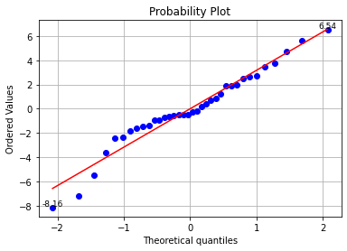

```
[-8.15833333 -7.2        -5.48333333 -3.6        -2.45833333 -2.38333333
 -1.8        -1.58333333 -1.48333333 -1.38333333 -0.95833333 -0.9
 -0.7        -0.65833333 -0.58333333 -0.48333333 -0.45833333 -0.45833333
 -0.25833333 -0.15833333  0.2         0.4         0.71666667  0.84166667
  1.2         1.9         1.91666667  2.          2.51666667  2.61666667
  2.74166667  3.44166667  3.8         4.7         5.61666667  6.54166667]
```

```python
# 用qq图进行正态性检验
res = res.astype(float) * 1
osm, osr = stats.probplot(res, dist = 'norm', plot = plt)
x1 = osm[0][0]
y1 = osm[1][0]
plt.text(x1, y1, '%.2f' % float(y1), ha = 'center', va = 'bottom',fontsize = 9)
x2 = osm[0][-1]
y2 = osm[1][-1]
plt.text(x2, y2, '%.2f' % float(y2), ha = 'center', va = 'bottom',fontsize = 9)
plt.grid()
plt.show()

print(osm[1])
```

【法2】利用Shapiro-Wilk检验 利用Shapiro-Wilk检验来做正态性检验，其原假设：样本数据符合正态分布。（注：适用于小样本） 利用方法stats.shapiro()检验正态性，输出结果中第一个为统计量，第二个为P值（统计量越接近 1 越表明数据和正态分布拟合的好，P值大于指定的显著性水平，接受原假设，认为样本来自服从正态分布的总体）

```python
# 用Shapiro-Wilk检验进行正态性检验
SW, pVal4 = stats.shapiro(res)
print(round(SW, 2))
print(round(pVal4, 2))

if pVal4 > alpha:
    print('\nAccept the null hypothesis.')
else:
    print('\nSince p-value > 0.05, reject the null null hypothesis')
```

```
0.96
0.26

Accept the null hypothesis.
```

由上述分析可知，统计量为 0.96，接近 1；且P值为 0.26，大于指定的显著性水平 0.05。故认为残差来自服从正态分布的总体。

# Q4: 估计食用这 3 种巧克力 1h 后血浆的总抗氧能力均值和误差的方差.

估计 μi 和 σ2 。

```python
# Estimation of Parameter(𝜎2 and 𝜇𝑖 )
mu = [round(np.mean(groups[i]), 3) for i in range(a)]
print('Estimate of the population mean：{0}'.format(mu))

sse = 0
for i in range(a):
    se = 0
    power_list = data[data[:,0] == list_type[i],1]
    for j in range(m):
        se += (power_list[j] - mu[i]) ** 2
    sse += se
var = round(sse / (a * (m - 1)),2)
print('An estimate of the population variance：{0}'.format(var))
```

```
Estimate of the population mean：[116.058, 100.7, 100.183]
An estimate of the population variance：10.43
```

由上述分析可知，食用这3种巧克力1h后血浆的总抗氧能力均值的估计值分别为：116.058，100.7，100.183 其方差的估计值为：10.43